# Risk Factor Analysis

## Outcome Variable

**Outcome Variable:** s03rec24

## Predictor Variables

**Intervention Variable:** hhwealth_quart

**Adjustment Set:**

unadjusted

## Stratifying Variables

The analysis was stratified on these variable(s):

- studyid
- country

## Data Summary

| studyid | country | A | n | nA | nAY0 | nAY1 |
| --- | --- | --- | --- | --- | --- | --- |
| ki0047075b-MAL-ED | BANGLADESH | Wealth Q4 | 80 | 26 | 24 | 2 |
| ki0047075b-MAL-ED | BANGLADESH | Wealth Q1 | 80 | 4 | 4 | 0 |
| ki0047075b-MAL-ED | BANGLADESH | Wealth Q2 | 80 | 15 | 14 | 1 |
| ki0047075b-MAL-ED | BANGLADESH | Wealth Q3 | 80 | 35 | 34 | 1 |
| ki0047075b-MAL-ED | BRAZIL | Wealth Q4 | 3 | 2 | 0 | 2 |
| ki0047075b-MAL-ED | BRAZIL | Wealth Q1 | 3 | 0 | 0 | 0 |
| ki0047075b-MAL-ED | BRAZIL | Wealth Q2 | 3 | 1 | 0 | 1 |
| ki0047075b-MAL-ED | BRAZIL | Wealth Q3 | 3 | 0 | 0 | 0 |
| ki0047075b-MAL-ED | INDIA | Wealth Q4 | 71 | 29 | 27 | 2 |
| ki0047075b-MAL-ED | INDIA | Wealth Q1 | 71 | 1 | 1 | 0 |
| ki0047075b-MAL-ED | INDIA | Wealth Q2 | 71 | 10 | 9 | 1 |
| ki0047075b-MAL-ED | INDIA | Wealth Q3 | 71 | 31 | 27 | 4 |
| ki0047075b-MAL-ED | NEPAL | Wealth Q4 | 42 | 21 | 20 | 1 |
| ki0047075b-MAL-ED | NEPAL | Wealth Q1 | 42 | 11 | 10 | 1 |
| ki0047075b-MAL-ED | NEPAL | Wealth Q2 | 42 | 6 | 5 | 1 |
| ki0047075b-MAL-ED | NEPAL | Wealth Q3 | 42 | 4 | 3 | 1 |
| ki0047075b-MAL-ED | PERU | Wealth Q4 | 35 | 1 | 1 | 0 |
| ki0047075b-MAL-ED | PERU | Wealth Q1 | 35 | 23 | 21 | 2 |
| ki0047075b-MAL-ED | PERU | Wealth Q2 | 35 | 10 | 8 | 2 |
| ki0047075b-MAL-ED | PERU | Wealth Q3 | 35 | 1 | 1 | 0 |
| ki0047075b-MAL-ED | SOUTH AFRICA | Wealth Q4 | 68 | 13 | 11 | 2 |
| ki0047075b-MAL-ED | SOUTH AFRICA | Wealth Q1 | 68 | 12 | 12 | 0 |
| ki0047075b-MAL-ED | SOUTH AFRICA | Wealth Q2 | 68 | 24 | 22 | 2 |
| ki0047075b-MAL-ED | SOUTH AFRICA | Wealth Q3 | 68 | 19 | 14 | 5 |
| ki0047075b-MAL-ED | TANZANIA, UNITED REPUBLIC OF | Wealth Q4 | 60 | 0 | 0 | 0 |
| ki0047075b-MAL-ED | TANZANIA, UNITED REPUBLIC OF | Wealth Q1 | 60 | 39 | 39 | 0 |
| ki0047075b-MAL-ED | TANZANIA, UNITED REPUBLIC OF | Wealth Q2 | 60 | 21 | 21 | 0 |
| ki0047075b-MAL-ED | TANZANIA, UNITED REPUBLIC OF | Wealth Q3 | 60 | 0 | 0 | 0 |
| ki1000108-CMC-V-BCS-2002 | INDIA | Wealth Q4 | 370 | 96 | 89 | 7 |
| ki1000108-CMC-V-BCS-2002 | INDIA | Wealth Q1 | 370 | 91 | 87 | 4 |
| ki1000108-CMC-V-BCS-2002 | INDIA | Wealth Q2 | 370 | 93 | 87 | 6 |
| ki1000108-CMC-V-BCS-2002 | INDIA | Wealth Q3 | 370 | 90 | 84 | 6 |
| ki1000108-IRC | INDIA | Wealth Q4 | 410 | 100 | 87 | 13 |
| ki1000108-IRC | INDIA | Wealth Q1 | 410 | 105 | 98 | 7 |
| ki1000108-IRC | INDIA | Wealth Q2 | 410 | 102 | 91 | 11 |
| ki1000108-IRC | INDIA | Wealth Q3 | 410 | 103 | 90 | 13 |
| ki1017093b-PROVIDE | BANGLADESH | Wealth Q4 | 684 | 174 | 165 | 9 |
| ki1017093b-PROVIDE | BANGLADESH | Wealth Q1 | 684 | 173 | 168 | 5 |
| ki1017093b-PROVIDE | BANGLADESH | Wealth Q2 | 684 | 166 | 158 | 8 |
| ki1017093b-PROVIDE | BANGLADESH | Wealth Q3 | 684 | 171 | 164 | 7 |
| ki1066203-TanzaniaChild2 | TANZANIA, UNITED REPUBLIC OF | Wealth Q4 | 2194 | 528 | 527 | 1 |
| ki1066203-TanzaniaChild2 | TANZANIA, UNITED REPUBLIC OF | Wealth Q1 | 2194 | 666 | 666 | 0 |
| ki1066203-TanzaniaChild2 | TANZANIA, UNITED REPUBLIC OF | Wealth Q2 | 2194 | 445 | 445 | 0 |
| ki1066203-TanzaniaChild2 | TANZANIA, UNITED REPUBLIC OF | Wealth Q3 | 2194 | 555 | 554 | 1 |
| ki1113344-GMS-Nepal | NEPAL | Wealth Q4 | 593 | 149 | 141 | 8 |
| ki1113344-GMS-Nepal | NEPAL | Wealth Q1 | 593 | 149 | 144 | 5 |
| ki1113344-GMS-Nepal | NEPAL | Wealth Q2 | 593 | 150 | 145 | 5 |
| ki1113344-GMS-Nepal | NEPAL | Wealth Q3 | 593 | 145 | 144 | 1 |
| ki1114097-CONTENT | PERU | Wealth Q4 | 210 | 50 | 44 | 6 |
| ki1114097-CONTENT | PERU | Wealth Q1 | 210 | 56 | 54 | 2 |
| ki1114097-CONTENT | PERU | Wealth Q2 | 210 | 52 | 45 | 7 |
| ki1114097-CONTENT | PERU | Wealth Q3 | 210 | 52 | 48 | 4 |

The following strata were considered:

- studyid: ki0047075b-MAL-ED, country: BANGLADESH
- studyid: ki0047075b-MAL-ED, country: BRAZIL
- studyid: ki0047075b-MAL-ED, country: INDIA
- studyid: ki0047075b-MAL-ED, country: NEPAL
- studyid: ki0047075b-MAL-ED, country: PERU
- studyid: ki0047075b-MAL-ED, country: SOUTH AFRICA
- studyid: ki0047075b-MAL-ED, country: TANZANIA, UNITED REPUBLIC OF
- studyid: ki1000108-CMC-V-BCS-2002, country: INDIA
- studyid: ki1000108-IRC, country: INDIA
- studyid: ki1017093b-PROVIDE, country: BANGLADESH
- studyid: ki1066203-TanzaniaChild2, country: TANZANIA, UNITED REPUBLIC OF
- studyid: ki1113344-GMS-Nepal, country: NEPAL
- studyid: ki1114097-CONTENT, country: PERU

### Dropped Strata

Some strata were dropped due to rare outcomes:

- studyid: ki0047075b-MAL-ED, country: BANGLADESH
- studyid: ki0047075b-MAL-ED, country: BRAZIL
- studyid: ki0047075b-MAL-ED, country: INDIA
- studyid: ki0047075b-MAL-ED, country: NEPAL
- studyid: ki0047075b-MAL-ED, country: PERU
- studyid: ki0047075b-MAL-ED, country: SOUTH AFRICA
- studyid: ki0047075b-MAL-ED, country: TANZANIA, UNITED REPUBLIC OF
- studyid: ki1000108-CMC-V-BCS-2002, country: INDIA
- studyid: ki1066203-TanzaniaChild2, country: TANZANIA, UNITED REPUBLIC OF
- studyid: ki1113344-GMS-Nepal, country: NEPAL
- studyid: ki1114097-CONTENT, country: PERU

## Methods Detail

We’re interested in the causal parameters $E[Y_a]$ for all values of $a \in \mathcal{A}$. These parameters represent the mean outcome if, possibly contrary to fact, we intervened to set all units to have $A=a$. Under the randomization and positivity assumptions, these are identified by the statistical parameters $\psi_a=E_W[E_{Y|A,W}(Y|A=a,W)]$. In addition, we’re interested in the mean of $Y$, $E[Y]$ under no intervention (the observed mean). We will estimate these parameters by using SuperLearner to fit the relevant likelihood factors – $E_{Y|A,W}(Y|A=a,W)$ and $p(A=a|W)$, and then updating our likelihood fit using a joint TMLE.

For unadjusted analyses ($W=\{\}$), initial likelihoods were estimated using Lrnr_glm to estimate the simple $E(Y|A)$ and Lrnr_mean to estimate $p(A)$. For adjusted analyses, a small library containing Lrnr_glmnet, Lrnr_xgboost, and Lrnr_mean was used.

Having estimated these parameters, we will then use the delta method to estimate relative risks and attributable risks relative to a prespecified baseline level of $A$.

# Results Detail

## Results Plots

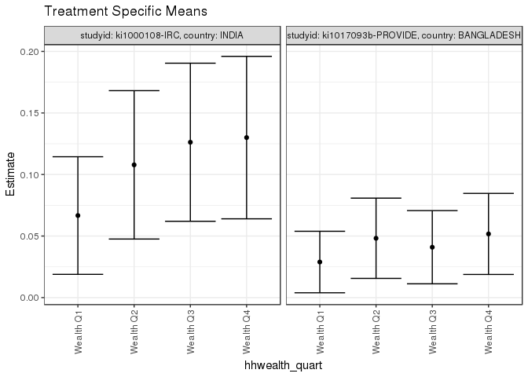

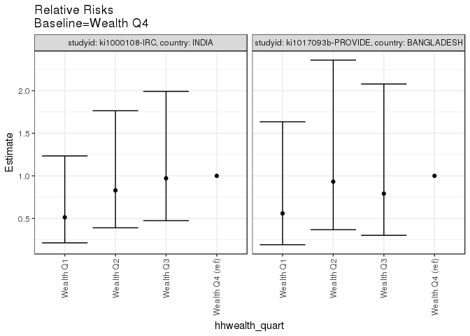

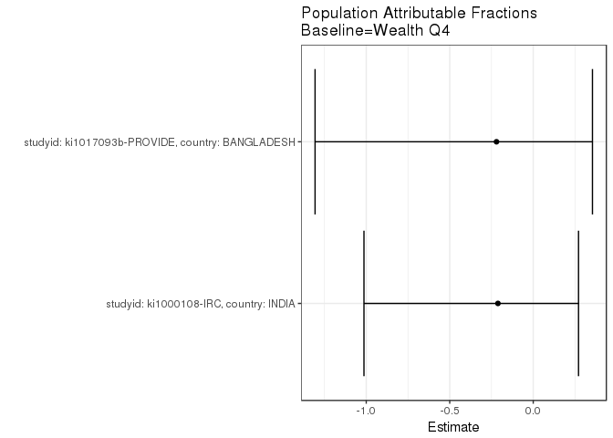

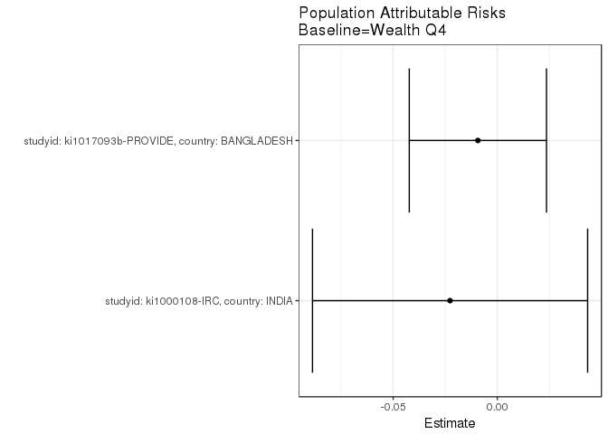

## Results Table

### Parameter: TSM

| studyid | country | intervention_level | baseline_level | estimate | ci_lower | ci_upper |
| --- | --- | --- | --- | --- | --- | --- |
| ki1000108-IRC | INDIA | Wealth Q4 | NA | 0.1300000 | 0.0640052 | 0.1959948 |
| ki1000108-IRC | INDIA | Wealth Q1 | NA | 0.0666667 | 0.0188965 | 0.1144368 |
| ki1000108-IRC | INDIA | Wealth Q2 | NA | 0.1078431 | 0.0475740 | 0.1681123 |
| ki1000108-IRC | INDIA | Wealth Q3 | NA | 0.1262136 | 0.0620017 | 0.1904255 |
| ki1017093b-PROVIDE | BANGLADESH | Wealth Q4 | NA | 0.0517241 | 0.0187931 | 0.0846552 |
| ki1017093b-PROVIDE | BANGLADESH | Wealth Q1 | NA | 0.0289017 | 0.0039192 | 0.0538843 |
| ki1017093b-PROVIDE | BANGLADESH | Wealth Q2 | NA | 0.0481928 | 0.0155883 | 0.0807972 |
| ki1017093b-PROVIDE | BANGLADESH | Wealth Q3 | NA | 0.0409357 | 0.0112161 | 0.0706552 |

### Parameter: E(Y)

| studyid | country | intervention_level | baseline_level | estimate | ci_lower | ci_upper |
| --- | --- | --- | --- | --- | --- | --- |
| ki1000108-IRC | INDIA | NA | NA | 0.1073171 | 0.1048683 | 0.1097659 |
| ki1017093b-PROVIDE | BANGLADESH | NA | NA | 0.0423977 | 0.0417401 | 0.0430552 |

### Parameter: RR

| studyid | country | intervention_level | baseline_level | estimate | ci_lower | ci_upper |
| --- | --- | --- | --- | --- | --- | --- |
| ki1000108-IRC | INDIA | Wealth Q4 | Wealth Q4 | 1.0000000 | 1.0000000 | 1.000000 |
| ki1000108-IRC | INDIA | Wealth Q1 | Wealth Q4 | 0.5128205 | 0.2131018 | 1.234081 |
| ki1000108-IRC | INDIA | Wealth Q2 | Wealth Q4 | 0.8295626 | 0.3899007 | 1.764998 |
| ki1000108-IRC | INDIA | Wealth Q3 | Wealth Q4 | 0.9708738 | 0.4731853 | 1.992023 |
| ki1017093b-PROVIDE | BANGLADESH | Wealth Q4 | Wealth Q4 | 1.0000000 | 1.0000000 | 1.000000 |
| ki1017093b-PROVIDE | BANGLADESH | Wealth Q1 | Wealth Q4 | 0.5587669 | 0.1909814 | 1.634821 |
| ki1017093b-PROVIDE | BANGLADESH | Wealth Q2 | Wealth Q4 | 0.9317269 | 0.3679815 | 2.359127 |
| ki1017093b-PROVIDE | BANGLADESH | Wealth Q3 | Wealth Q4 | 0.7914230 | 0.3013308 | 2.078614 |

### Parameter: PAR

| studyid | country | intervention_level | baseline_level | estimate | ci_lower | ci_upper |
| --- | --- | --- | --- | --- | --- | --- |
| ki1000108-IRC | INDIA | Wealth Q4 | NA | -0.0226829 | -0.0887231 | 0.0433573 |
| ki1017093b-PROVIDE | BANGLADESH | Wealth Q4 | NA | -0.0093265 | -0.0422641 | 0.0236111 |

### Parameter: PAF

| studyid | country | intervention_level | baseline_level | estimate | ci_lower | ci_upper |
| --- | --- | --- | --- | --- | --- | --- |
| ki1000108-IRC | INDIA | Wealth Q4 | NA | -0.2113636 | -1.013575 | 0.2712453 |
| ki1017093b-PROVIDE | BANGLADESH | Wealth Q4 | NA | -0.2199762 | -1.306397 | 0.3546896 |